# Project_Model_Tuning_ReneWind_FullCode

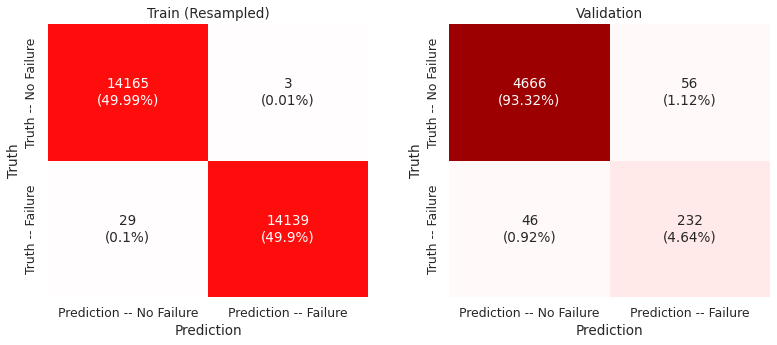

```python
# Plotting the confusion matrices of the model on training and validation sets

# Reconstructing the training set
y_recon = bgc_over.predict(X_train_over)
# Forecasting the validation set
y_pred = bgc_over.predict(X_valid)

# Plotting the heatmaps of confusion matrices
plt.figure(figsize = (11, 5));
plt.subplot(121);
plot_cm(y_train_over, y_recon);
plt.title('Train (Resampled)');
plt.subplot(122);
plot_cm(y_valid, y_pred);
plt.title('Validation');
plt.tight_layout(w_pad = 3);
```

```python
# Reporting the performance metrics of the model on training and validation sets
bgc_over_perform = model_eval(bgc_over, X_train_over, X_valid, y_train_over, y_valid)
bgc_over_perform
```

|  | Accuracy | Recall | Precision | F1 | Specificity |
| --- | --- | --- | --- | --- | --- |
| Train | 0.999 | 0.998 | 1.000 | 0.999 | 1.000 |
| Validation | 0.980 | 0.835 | 0.806 | 0.820 | 0.988 |

```python
# Finding the region of uncertainty for the recall score of the model

# Setting the strategy for splitting the data into 10 random folds
kfold = StratifiedKFold(n_splits = 10, shuffle = True, random_state = 1)

# Calculating the cross-validated scores
cv_results = cross_val_score(bgc_over, X_train_over, y_train_over, scoring = 'recall', cv = kfold, n_jobs = -1)
cv_mean = cv_results.mean()
cv_std  = cv_results.std()

# Reporting the model's average recall score and confidence interval
print('The average recall score of the model is {} and,'.format(round(cv_mean, 3)),
      'with 95% certainty, its recall score resides between {} and {}.'.format(
          round(cv_mean-2*cv_std, 3), round(cv_mean+2*cv_std, 3)))
```

```
The average recall score of the model is 0.978 and, with 95% certainty, its recall score resides between 0.972 and 0.984.
```

**`Random Forest`**

```python
# Building the oversampled model
rfc_over = RandomForestClassifier(random_state = 1)
rfc_over = rfc_over.fit(X_train_over, y_train_over)
```

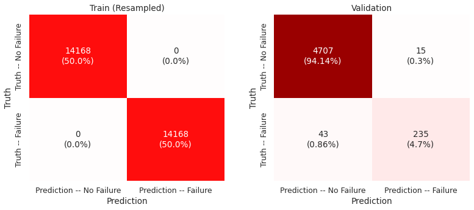

```python
# Plotting the confusion matrices of the model on training and validation sets

# Reconstructing the training set
y_recon = rfc_over.predict(X_train_over)
# Forecasting the validation set
y_pred = rfc_over.predict(X_valid)

# Plotting the heatmaps of confusion matrices
plt.figure(figsize = (11, 5));
plt.subplot(121);
plot_cm(y_train_over, y_recon);
plt.title('Train (Resampled)');
plt.subplot(122);
plot_cm(y_valid, y_pred);
plt.title('Validation');
plt.tight_layout(w_pad = 3);
```

```python
# Reporting the performance metrics of the model on training and validation sets
rfc_over_perform = model_eval(rfc_over, X_train_over, X_valid, y_train_over, y_valid)
rfc_over_perform
```

|  | Accuracy | Recall | Precision | F1 | Specificity |
| --- | --- | --- | --- | --- | --- |
| Train | 1.000 | 1.000 | 1.000 | 1.000 | 1.000 |
| Validation | 0.988 | 0.845 | 0.940 | 0.890 | 0.997 |

```python
# Finding the region of uncertainty for the recall score of the model

# Setting the strategy for splitting the data into 10 random folds
kfold = StratifiedKFold(n_splits = 10, shuffle = True, random_state = 1)

# Calculating the cross-validated scores
cv_results = cross_val_score(rfc_over, X_train_over, y_train_over, scoring = 'recall', cv = kfold, n_jobs = -1)
cv_mean = cv_results.mean()
cv_std  = cv_results.std()

# Reporting the model's average recall score and confidence interval
print('The average recall score of the model is {} and,'.format(round(cv_mean, 3)),
      'with 95% certainty, its recall score resides between {} and {}.'.format(
          round(cv_mean-2*cv_std, 3), round(cv_mean+2*cv_std, 3)))
```

```
The average recall score of the model is 0.985 and, with 95% certainty, its recall score resides between 0.978 and 0.991.
```

**`Adaptive Boosting Classifier`**

```python
# Building the oversampled model
abc_over = AdaBoostClassifier(random_state = 1)
abc_over = abc_over.fit(X_train_over, y_train_over)
```

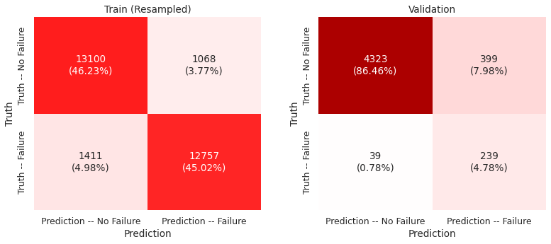

```python
# Plotting the confusion matrices of the model on training and validation sets

# Reconstructing the training set
y_recon = abc_over.predict(X_train_over)
# Forecasting the validation set
y_pred = abc_over.predict(X_valid)

# Plotting the heatmaps of confusion matrices
plt.figure(figsize = (11, 5));
plt.subplot(121);
plot_cm(y_train_over, y_recon);
plt.title('Train (Resampled)');
plt.subplot(122);
plot_cm(y_valid, y_pred);
plt.title('Validation');
plt.tight_layout(w_pad = 3);
```

```python
# Reporting the performance metrics of the model on training and validation sets
abc_over_perform = model_eval(abc_over, X_train_over, X_valid, y_train_over, y_valid)
abc_over_perform
```

|  | Accuracy | Recall | Precision | F1 | Specificity |
| --- | --- | --- | --- | --- | --- |
| Train | 0.913 | 0.900 | 0.923 | 0.911 | 0.925 |
| Validation | 0.912 | 0.860 | 0.375 | 0.522 | 0.916 |

```python
# Finding the region of uncertainty for the recall score of the model

# Setting the strategy for splitting the data into 10 random folds
kfold = StratifiedKFold(n_splits = 10, shuffle = True, random_state = 1)

# Calculating the cross-validated scores
cv_results = cross_val_score(abc_over, X_train_over, y_train_over, scoring = 'recall', cv = kfold, n_jobs = -1)
cv_mean = cv_results.mean()
cv_std  = cv_results.std()

# Reporting the model's average recall score and confidence interval
print('The average recall score of the model is {} and,'.format(round(cv_mean, 3)),
      'with 95% certainty, its recall score resides between {} and {}.'.format(
          round(cv_mean-2*cv_std, 3), round(cv_mean+2*cv_std, 3)))
```

```
The average recall score of the model is 0.899 and, with 95% certainty, its recall score resides between 0.882 and 0.915.
```

**`Gradient Boosting Classifier`**

```python
# Building the oversampled model
gbc_over = GradientBoostingClassifier(random_state = 1)
gbc_over = gbc_over.fit(X_train_over, y_train_over)
```

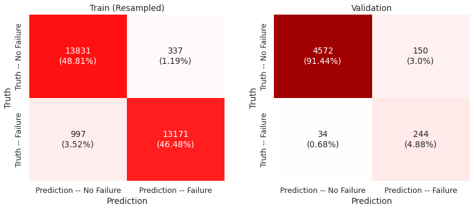

```python
# Plotting the confusion matrices of the model on training and validation sets

# Reconstructing the training set
y_recon = gbc_over.predict(X_train_over)
# Forecasting the validation set
y_pred = gbc_over.predict(X_valid)

# Plotting the heatmaps of confusion matrices
plt.figure(figsize = (11, 5));
plt.subplot(121);
plot_cm(y_train_over, y_recon);
plt.title('Train (Resampled)');
plt.subplot(122);
plot_cm(y_valid, y_pred);
plt.title('Validation');
plt.tight_layout(w_pad = 3);
```

```python
# Reporting the performance metrics of the model on training and validation sets
gbc_over_perform = model_eval(gbc_over, X_train_over, X_valid, y_train_over, y_valid)
gbc_over_perform
```

|  | Accuracy | Recall | Precision | F1 | Specificity |
| --- | --- | --- | --- | --- | --- |
| Train | 0.953 | 0.930 | 0.975 | 0.952 | 0.976 |
| Validation | 0.963 | 0.878 | 0.619 | 0.726 | 0.968 |

```python
# Finding the region of uncertainty for the recall score of the model

# Setting the strategy for splitting the data into 10 random folds
kfold = StratifiedKFold(n_splits = 10, shuffle = True, random_state = 1)

# Calculating the cross-validated scores
cv_results = cross_val_score(gbc_over, X_train_over, y_train_over, scoring = 'recall', cv = kfold, n_jobs = -1)
cv_mean = cv_results.mean()
cv_std  = cv_results.std()

# Reporting the model's average recall score and confidence interval
print('The average recall score of the model is {} and,'.format(round(cv_mean, 3)),
      'with 95% certainty, its recall score resides between {} and {}.'.format(
          round(cv_mean-2*cv_std, 3), round(cv_mean+2*cv_std, 3)))
```

```
The average recall score of the model is 0.927 and, with 95% certainty, its recall score resides between 0.916 and 0.937.
```

**`XGBoost Classifier`**

```python
# Building the oversampled model
xgbc_over = XGBClassifier(eval_metric = 'logloss', random_state = 1)
xgbc_over = xgbc_over.fit(X_train_over, y_train_over)
```

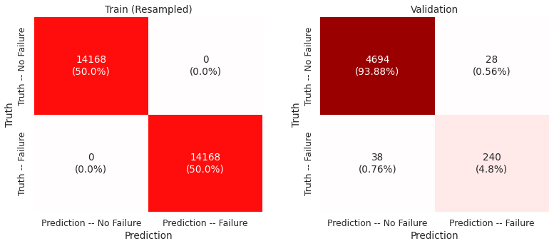

```python
# Plotting the confusion matrices of the model on training and validation sets

# Reconstructing the training set
y_recon = xgbc_over.predict(X_train_over)
# Forecasting the validation set
y_pred = xgbc_over.predict(X_valid)

# Plotting the heatmaps of confusion matrices
plt.figure(figsize = (11, 5));
plt.subplot(121);
plot_cm(y_train_over, y_recon);
plt.title('Train (Resampled)');
plt.subplot(122);
plot_cm(y_valid, y_pred);
plt.title('Validation');
plt.tight_layout(w_pad = 3);
```

```python
# Reporting the performance metrics of the model on training and validation sets
xgbc_over_perform = model_eval(xgbc_over, X_train_over, X_valid, y_train_over, y_valid)
xgbc_over_perform
```

|  | Accuracy | Recall | Precision | F1 | Specificity |
| --- | --- | --- | --- | --- | --- |
| Train | 1.000 | 1.000 | 1.000 | 1.000 | 1.000 |
| Validation | 0.987 | 0.863 | 0.896 | 0.879 | 0.994 |

```python
# Finding the region of uncertainty for the recall score of the model

# Setting the strategy for splitting the data into 10 random folds
kfold = StratifiedKFold(n_splits = 10, shuffle = True, random_state = 1)

# Calculating the cross-validated scores
cv_results = cross_val_score(xgbc_over, X_train_over, y_train_over, scoring = 'recall', cv = kfold, n_jobs = -1)
cv_mean = cv_results.mean()
cv_std  = cv_results.std()

# Reporting the model's average recall score and confidence interval
print('The average recall score of the model is {} and,'.format(round(cv_mean, 3)),
      'with 95% certainty, its recall score resides between {} and {}.'.format(
          round(cv_mean-2*cv_std, 3), round(cv_mean+2*cv_std, 3)))
```

```
The average recall score of the model is 0.99 and, with 95% certainty, its recall score resides between 0.984 and 0.996.
```

**`Comparison`**

```python
# Comparison of all oversampled models on training set
oversampled_compare_train = pd.concat([lrc_over_perform, dtr_over_perform, bgc_over_perform,
                                       rfc_over_perform, abc_over_perform, gbc_over_perform,
                                       xgbc_over_perform])[::2]
oversampled_compare_train.index = ['Logistic Regression (Oversampled)', 'Decision Tree (Oversampled)',
                                   'Bagging (Oversampled)', 'Random Forest (Oversampled)',
                                   'AdaBoost (Oversampled)','Gradient Boosting (Oversampled)',
                                   'XGBoost (Oversampled)']
oversampled_compare_train.sort_values(by = 'Recall', ascending = False)
```

|  | Accuracy | Recall | Precision | F1 | Specificity |
| --- | --- | --- | --- | --- | --- |
| Decision Tree (Oversampled) | 1.000 | 1.000 | 1.000 | 1.000 | 1.000 |
| Random Forest (Oversampled) | 1.000 | 1.000 | 1.000 | 1.000 | 1.000 |
| XGBoost (Oversampled) | 1.000 | 1.000 | 1.000 | 1.000 | 1.000 |
| Bagging (Oversampled) | 0.999 | 0.998 | 1.000 | 0.999 | 1.000 |
| Gradient Boosting (Oversampled) | 0.953 | 0.930 | 0.975 | 0.952 | 0.976 |
| AdaBoost (Oversampled) | 0.913 | 0.900 | 0.923 | 0.911 | 0.925 |
| Logistic Regression (Oversampled) | 0.880 | 0.884 | 0.878 | 0.881 | 0.877 |

```python
# Comparison of all oversampled models on training set
oversampled_compare_valid = pd.concat([lrc_over_perform, dtr_over_perform, bgc_over_perform,
                                       rfc_over_perform, abc_over_perform, gbc_over_perform,
                                       xgbc_over_perform])[1::2]
oversampled_compare_valid.index = ['Logistic Regression (Oversampled)', 'Decision Tree (Oversampled)',
                                   'Bagging (Oversampled)', 'Random Forest (Oversampled)',
                                   'AdaBoost (Oversampled)','Gradient Boosting (Oversampled)',
                                   'XGBoost (Oversampled)']
oversampled_compare_valid.sort_values(by = 'Recall', ascending = False)
```

|  | Accuracy | Recall | Precision | F1 | Specificity |
| --- | --- | --- | --- | --- | --- |
| Gradient Boosting (Oversampled) | 0.963 | 0.878 | 0.619 | 0.726 | 0.968 |
| XGBoost (Oversampled) | 0.987 | 0.863 | 0.896 | 0.879 | 0.994 |
| AdaBoost (Oversampled) | 0.912 | 0.860 | 0.375 | 0.522 | 0.916 |
| Logistic Regression (Oversampled) | 0.868 | 0.849 | 0.277 | 0.418 | 0.870 |
| Random Forest (Oversampled) | 0.988 | 0.845 | 0.940 | 0.890 | 0.997 |
| Bagging (Oversampled) | 0.980 | 0.835 | 0.806 | 0.820 | 0.988 |
| Decision Tree (Oversampled) | 0.949 | 0.770 | 0.530 | 0.628 | 0.960 |

#### Observations:

- Oversampling has significantly improved the recall score on the training and more importantly the validation set, and now the validation recall score hovers around 0.85 (except for the Decision Tree classifier whose recall is 0.77), as the bias toward the majority class has been eliminated.
- All models still suffer from overfitting. Even the Logistic Regression and AdaBoost Classifiers that weren't troubled by this problem very seriously before, now see significant drop in their precision and F1 scores moving from training to validation set.
- It is noteworthy how well the XGBoost Classifier performs on both sets. While the gap between recall score on training and validation has been reduced by oversampling, the validation precision score has also remained quite high.

### Undersampling

Here, we rebuild the baseline models for downsampled data.

```python
# Setting the undersampling strategy
undersampling_scheme = RandomUnderSampler(sampling_strategy = 1, random_state = 1)
# Constructing the undersampled dataset
X_train_under, y_train_under = undersampling_scheme.fit_resample(X_train, y_train)

# Comparing the oversampled data with the original data
print('The counts of target classes before undersampling:\n', y_train.value_counts(),
      end = '\n' + '**'*35 + '\n', sep = '')
print('The counts of target classes after undersampling:\n', y_train_under.value_counts(),
      end = '\n' + '**'*35 + '\n', sep = '')
print('The fractions of target classes before undersampling:\n', y_train.value_counts(1),
      end = '\n' + '**'*35 + '\n', sep = '')
print('The fractions of target classes after undersampling:\n', y_train_under.value_counts(1),
      end = '\n' + '**'*35 + '\n', sep = '')
print('The size of training set before undersampling:', X_train.shape)
print('The size of training set after undersampling:', X_train_under.shape)
```

```
The counts of target classes before undersampling:
0    14168
1      832
Name: Target, dtype: int64
The counts of target classes after undersampling:
0    832
1    832
Name: Target, dtype: int64
The fractions of target classes before undersampling:
0   0.945
1   0.055
Name: Target, dtype: float64
The fractions of target classes after undersampling:
0   0.500
1   0.500
Name: Target, dtype: float64
The size of training set before undersampling: (15000, 40)
The size of training set after undersampling: (1664, 40)
```

**`Logistic Regression`**

```python
# Building the undersampled model
lrc_under = LogisticRegression(solver = 'liblinear', max_iter = 1000, random_state = 1)
lrc_under = lrc_under.fit(X_train_under, y_train_under)
```

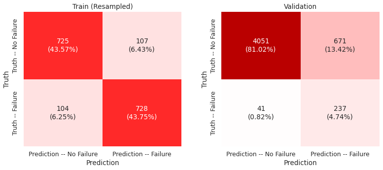

```python
# Plotting the confusion matrices of the model on training and validation sets

# Reconstructing the training set
y_recon = lrc_under.predict(X_train_under)
# Forecasting the validation set
y_pred = lrc_under.predict(X_valid)

# Plotting the heatmaps of confusion matrices
plt.figure(figsize = (11, 5));
plt.subplot(121);
plot_cm(y_train_under, y_recon);
plt.title('Train (Resampled)');
plt.subplot(122);
plot_cm(y_valid, y_pred);
plt.title('Validation');
plt.tight_layout(w_pad = 3);
```

```python
# Reporting the performance metrics of the model on training and validation sets
lrc_under_perform = model_eval(lrc_under, X_train_under, X_valid, y_train_under, y_valid)
lrc_under_perform
```

|  | Accuracy | Recall | Precision | F1 | Specificity |
| --- | --- | --- | --- | --- | --- |
| Train | 0.873 | 0.875 | 0.872 | 0.873 | 0.871 |
| Validation | 0.858 | 0.853 | 0.261 | 0.400 | 0.858 |

```python
# Finding the region of uncertainty for the recall score of the model

# Setting the strategy for splitting the data into 10 random folds
kfold = StratifiedKFold(n_splits = 10, shuffle = True, random_state = 1)

# Calculating the cross-validated scores
cv_results = cross_val_score(lrc_under, X_train_under, y_train_under, scoring = 'recall', cv = kfold, n_jobs = -1)
cv_mean = cv_results.mean()
cv_std  = cv_results.std()

# Reporting the model's average recall score and confidence interval
print('The average recall score of the model is {} and,'.format(round(cv_mean, 3)),
      'with 95% certainty, its recall score resides between {} and {}.'.format(
          round(cv_mean-2*cv_std, 3), round(cv_mean+2*cv_std, 3)))
```

```
The average recall score of the model is 0.868 and, with 95% certainty, its recall score resides between 0.81 and 0.925.
```

**`Decision Tree`**

```python
# Building the undersampled model
dtr_under = DecisionTreeClassifier(random_state = 1)
dtr_under = dtr_under.fit(X_train_under, y_train_under)
```

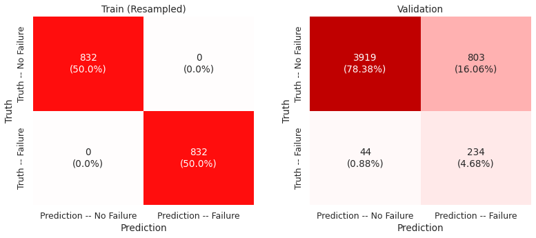

```python
# Plotting the confusion matrices of the model on training and validation sets

# Reconstructing the training set
y_recon = dtr_under.predict(X_train_under)
# Forecasting the validation set
y_pred = dtr_under.predict(X_valid)

# Plotting the heatmaps of confusion matrices
plt.figure(figsize = (11, 5));
plt.subplot(121);
plot_cm(y_train_under, y_recon);
plt.title('Train (Resampled)');
plt.subplot(122);
plot_cm(y_valid, y_pred);
plt.title('Validation');
plt.tight_layout(w_pad = 3);
```

```python
# Reporting the performance metrics of the model on training and validation sets
dtr_under_perform = model_eval(dtr_under, X_train_under, X_valid, y_train_under, y_valid)
dtr_under_perform
```

|  | Accuracy | Recall | Precision | F1 | Specificity |
| --- | --- | --- | --- | --- | --- |
| Train | 1.000 | 1.000 | 1.000 | 1.000 | 1.000 |
| Validation | 0.831 | 0.842 | 0.226 | 0.356 | 0.830 |

```python
# Finding the region of uncertainty for the recall score of the model

# Setting the strategy for splitting the data into 10 random folds
kfold = StratifiedKFold(n_splits = 10, shuffle = True, random_state = 1)

# Calculating the cross-validated scores
cv_results = cross_val_score(dtr_under, X_train_under, y_train_under, scoring = 'recall', cv = kfold, n_jobs = -1)
cv_mean = cv_results.mean()
cv_std  = cv_results.std()

# Reporting the model's average recall score and confidence interval
print('The average recall score of the model is {} and,'.format(round(cv_mean, 3)),
      'with 95% certainty, its recall score resides between {} and {}.'.format(
          round(cv_mean-2*cv_std, 3), round(cv_mean+2*cv_std, 3)))
```

```
The average recall score of the model is 0.867 and, with 95% certainty, its recall score resides between 0.818 and 0.915.
```

**`Bagging Classifier`**

```python
# Building the undersampled model
bgc_under = BaggingClassifier(random_state = 1)
bgc_under = bgc_under.fit(X_train_under, y_train_under)
```

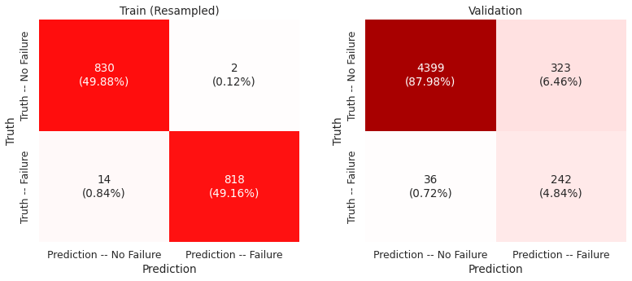

```python
# Plotting the confusion matrices of the model on training and validation sets

# Reconstructing the training set
y_recon = bgc_under.predict(X_train_under)
# Forecasting the validation set
y_pred = bgc_under.predict(X_valid)

# Plotting the heatmaps of confusion matrices
plt.figure(figsize = (11, 5));
plt.subplot(121);
plot_cm(y_train_under, y_recon);
plt.title('Train (Resampled)');
plt.subplot(122);
plot_cm(y_valid, y_pred);
plt.title('Validation');
plt.tight_layout(w_pad = 3);
```